# People Analytics and Employee Retention

Employee attrition is very important. Companies spend lots of resources, money and valuable time to train their employees to get the best results and hence if the employee leaves the company due to some reason it is a great loss of human resource for the company. Therefore, understanding why employees leave is very important for businesses to maximize efficiency and reduce training cost which translates into greater profit.

HR truly needs to start thinking outside of its traditional thinking and methodologies to powerfully address the HR challenges and issues in the future.

```python
import numpy as np # linear algebra
import pandas as pd
df = pd.read_csv('data/HR_comma_sep.csv')
print df.head()
```

```
   satisfaction_level  last_evaluation  number_project  average_montly_hours  \
0                0.38             0.53               2                   157
1                0.80             0.86               5                   262
2                0.11             0.88               7                   272
3                0.72             0.87               5                   223
4                0.37             0.52               2                   159

   time_spend_company  Work_accident  left  promotion_last_5years  sales  \
0                   3              0     1                      0  sales
1                   6              0     1                      0  sales
2                   4              0     1                      0  sales
3                   5              0     1                      0  sales
4                   3              0     1                      0  sales

   salary
0     low
1  medium
2  medium
3     low
4     low
```

```python
# Describing the dataset
df.describe().T
```

|  | count | mean | std | min | 25% | 50% | 75% | max |
| --- | --- | --- | --- | --- | --- | --- | --- | --- |
| satisfaction_level | 14999.0 | 0.612834 | 0.248631 | 0.09 | 0.44 | 0.64 | 0.82 | 1.0 |
| last_evaluation | 14999.0 | 0.716102 | 0.171169 | 0.36 | 0.56 | 0.72 | 0.87 | 1.0 |
| number_project | 14999.0 | 3.803054 | 1.232592 | 2.00 | 3.00 | 4.00 | 5.00 | 7.0 |
| average_montly_hours | 14999.0 | 201.050337 | 49.943099 | 96.00 | 156.00 | 200.00 | 245.00 | 310.0 |
| time_spend_company | 14999.0 | 3.498233 | 1.460136 | 2.00 | 3.00 | 3.00 | 4.00 | 10.0 |
| Work_accident | 14999.0 | 0.144610 | 0.351719 | 0.00 | 0.00 | 0.00 | 0.00 | 1.0 |
| left | 14999.0 | 0.238083 | 0.425924 | 0.00 | 0.00 | 0.00 | 0.00 | 1.0 |
| promotion_last_5years | 14999.0 | 0.021268 | 0.144281 | 0.00 | 0.00 | 0.00 | 0.00 | 1.0 |

```python
df.describe(include=['object'])
```

|  | sales | salary |
| --- | --- | --- |
| count | 14999 | 14999 |
| unique | 10 | 3 |
| top | sales | low |
| freq | 4140 | 7316 |

[output not shown]

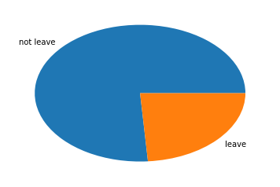

```python
import seaborn as sns
import matplotlib.pyplot as plt
%matplotlib inline

# Getting the count of people that leave and not
leftcounts=df['left'].value_counts()
print("Left count is \n",leftcounts[1])
total = leftcounts[0]+leftcounts[1]*0.01
print "% of people who left : ",leftcounts[1]/(total)*100

# Using matplotlib pie chart and label the pie chart

plt.pie(leftcounts,labels=['not leave','leave']);
```

```python
leftdf = df[df['left']==1]
notleftdf =df[df['left']==0]

#tprint leftdf
```

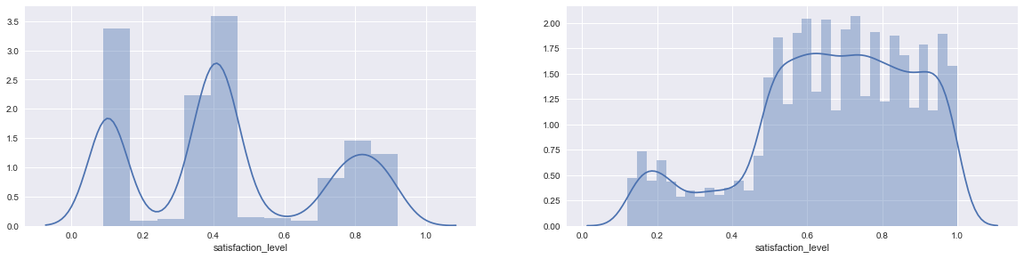

```python
# Create a figure instance, and the two subplots
fig = plt.figure(figsize=(20,10))
ax1 = fig.add_subplot(221)
ax2 = fig.add_subplot(222)

# Tell pointplot to plot on ax1 with the ax argument (satisfaction level)
sns.distplot(leftdf['satisfaction_level'],ax = ax1);
# Tell the factorplot to plot on ax2 with the ax argument (satisfaction level)
sns.distplot(notleftdf['satisfaction_level'],ax = ax2);
```

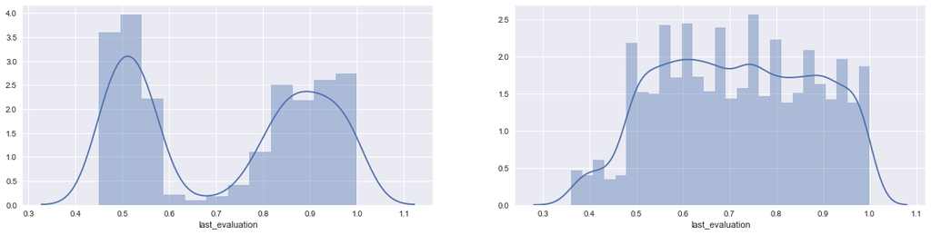

```python
# Create a figure instance, and the two subplots
fig = plt.figure(figsize=(20,10))
ax1 = fig.add_subplot(221)
ax2 = fig.add_subplot(222)

# Tell pointplot to plot on ax1 with the ax argument
sns.distplot(leftdf['last_evaluation'], kde=True,ax=ax1);

# Tell the factorplot to plot on ax2 with the ax argument
sns.distplot(notleftdf['last_evaluation'], kde=True,ax=ax2);
```

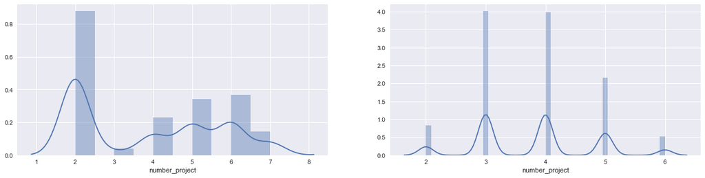

```python
# Create a figure instance, and the two subplots
fig = plt.figure(figsize=(20,10))
ax1 = fig.add_subplot(221)
ax2 = fig.add_subplot(222)

sns.distplot(leftdf['number_project'], kde=True,ax=ax1);

sns.distplot(notleftdf['number_project'], kde=True,ax=ax2);
```

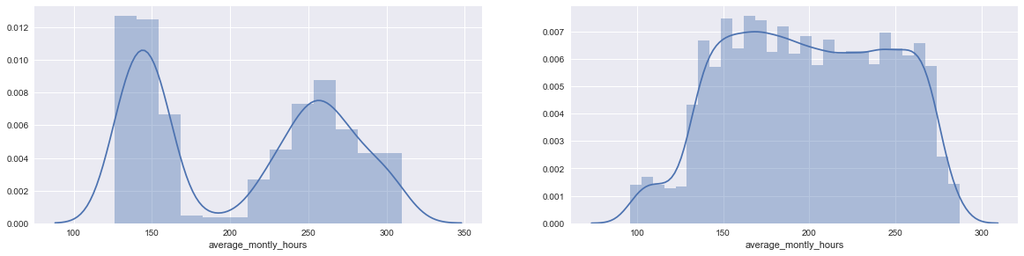

```python
# Create a figure instance, and the two subplots
fig = plt.figure(figsize=(20,10))
ax1 = fig.add_subplot(221)
ax2 = fig.add_subplot(222)

sns.distplot(leftdf['average_montly_hours'], kde=True,ax=ax1);

sns.distplot(notleftdf['average_montly_hours'], kde=True,ax=ax2);
```

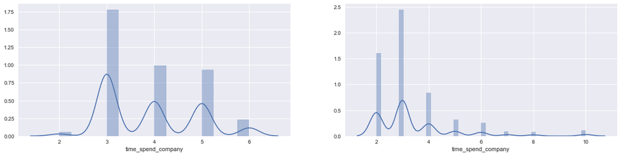

```python
# create a figure with two subplots
fig = plt.figure(figsize=(20,10))
ax1 = fig.add_subplot(221)
ax2 = fig.add_subplot(222)

lefttimespendcompanycounts = leftdf['time_spend_company'].value_counts()
notlefttimespendcompanycounts = notleftdf['time_spend_company'].value_counts()


sns.distplot(leftdf['time_spend_company'], kde=True,ax=ax1);

sns.distplot(notleftdf['time_spend_company'], kde=True,ax=ax2);
```

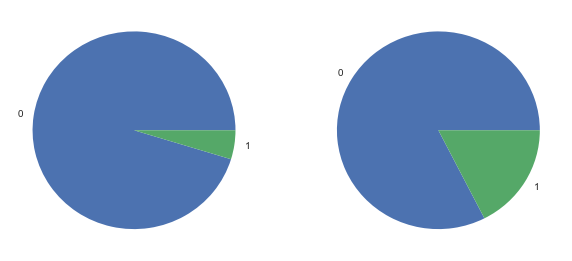

```python
#create a figure with two subplots
fig = plt.figure(figsize=(10,10))
ax1 = fig.add_subplot(221)
ax2 = fig.add_subplot(222)

# Do the value counts of work accident
leftworkaccidentcounts = leftdf['Work_accident'].value_counts()
notleftworkaccidentcounts = notleftdf['Work_accident'].value_counts()


# plot each pie chart in a separate subplot
ax1.pie(leftworkaccidentcounts,labels=leftworkaccidentcounts.index);
ax2.pie(notleftworkaccidentcounts,labels=notleftworkaccidentcounts.index);
```

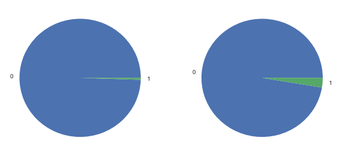

```python
# create a figure with two subplots
fig = plt.figure(figsize=(10,10))
ax1 = fig.add_subplot(221)
ax2 = fig.add_subplot(222)

leftpromotioncounts = leftdf['promotion_last_5years'].value_counts()
notleftpromotioncounts = notleftdf['promotion_last_5years'].value_counts()


# plot each pie chart in a separate subplot
ax1.pie(leftpromotioncounts,labels=leftpromotioncounts.index);
ax2.pie(notleftpromotioncounts,labels=notleftpromotioncounts.index);
```

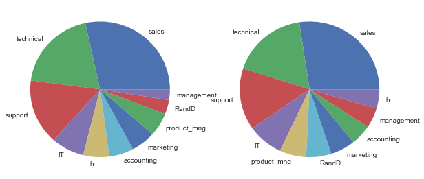

```python
# create a figure with two subplots
fig = plt.figure(figsize=(10,10))
ax1 = fig.add_subplot(221)
ax2 = fig.add_subplot(222)

leftdepartmentcounts = leftdf['sales'].value_counts()
notleftdepartmentcounts = notleftdf['sales'].value_counts()


# plot each pie chart in a separate subplot
ax1.pie(leftdepartmentcounts,labels=leftdepartmentcounts.index);
ax2.pie(notleftdepartmentcounts,labels=notleftdepartmentcounts.index);
```